# Wave Mechanics

Author

Daniel Fischer

# Wave Mechanics: Overview and Plan

This chapter introduces the wave-mechanical description of quantum particles. We begin with **electron interference** because it exposes the central problem directly: electrons are detected as localized particles, but the distribution of many detection events can show interference, a characteristic wave phenomenon.

The specific goals for this chapter are:

1. Discuss **electron interference** and the experimental evidence for matter waves.
2. Review the description of **waves**, including amplitude, wavelength, frequency, phase, and the complex representation of a wave.
3. Introduce **superposition and interference** and show why relative phase determines an interference pattern.
4. Introduce **probability distributions** and the Born interpretation of the quantum-mechanical wave function.
5. Introduce the **de Broglie relations** between momentum and wave vector and between energy and frequency.
6. Motivate the **Schrödinger equation** and its description of the time evolution of a quantum state.

**ImportantCore Knowledge — Know**

A harmonic plane wave can be written in complex form as

$$\psi(\vec r,t)
=
A e^{i(\vec k\cdot\vec r-\omega t+\phi)},$$

with

$$k=\frac{2\pi}{\lambda},
\qquad
\omega=2\pi f.$$

Quantum-mechanical amplitudes obey the **superposition principle**,

$$\psi=\psi_1+\psi_2,$$

and the measurable position probability density is given by the **Born rule**,

$$\boxed{
p(\vec r,t)=|\psi(\vec r,t)|^2.
}$$

For a normalizable state,

$$\boxed{
\int_{\mathbb R^3}|\psi(\vec r,t)|^2\,d^3r=1.
}$$

Matter-wave quantities are related to particle quantities by the de Broglie relations

$$\boxed{
\vec p=\hbar\vec k,
\qquad
E=\hbar\omega.
}$$

In position representation, the momentum operator is

$$\boxed{
\hat{\vec p}=-i\hbar\vec\nabla.
}$$

The time evolution of a nonrelativistic quantum state is governed by the Schrödinger equation,

$$\boxed{
i\hbar\frac{\partial}{\partial t}\psi
=
\hat H\psi.
}$$

For a particle in a potential $V(\vec r,t)$,

$$\boxed{
\hat H
=
-\frac{\hbar^2}{2m}\nabla^2+V.
}$$

If the Hamiltonian has no explicit time dependence, states of definite energy satisfy

$$\boxed{
\hat H\phi=E\phi
}$$

and have time dependence

$$\psi(\vec r,t)
=
\phi(\vec r)e^{-iEt/\hbar}.$$

**NoteWorking Knowledge — Understand**

You should understand that

- electrons are detected at localized positions, while repeated measurements can produce diffraction and interference patterns;
- a quantum state is described by a generally complex **probability amplitude** $\psi$, while $|\psi|^2$ gives the probability density;
- probability amplitudes add before taking the absolute square, so that interference arises from the cross terms in

  $$|\psi_1+\psi_2|^2;$$
- the amount of interference depends on the **relative phase** between the contributing amplitudes;
- the de Broglie relations connect the wave description $(\omega,\vec k)$ with the particle quantities $(E,\vec p)$;
- an ideal plane wave has a precisely defined momentum but is completely delocalized, whereas a localized state must be formed from a superposition of different wave vectors;
- the differential forms of the energy and momentum operators can be motivated by their action on plane waves;
- the Schrödinger equation is the fundamental dynamical equation of nonrelativistic quantum mechanics; the argument given in this chapter motivates its form but does not derive it from classical mechanics;
- an energy eigenstate evolves only by a time-dependent phase factor, so its position probability density is time independent.

The detailed interference derivations, Fourier-transform formulas, and Gaussian wave-packet example are included to develop these ideas, but the intermediate algebra is not intended as material to memorize.

# 1. Electron Interference and Matter Waves

## 1.1 What is an electron?

By the beginning of the 20th century, the electron was well established as a constituent of matter with a definite electric charge and mass. These properties naturally suggested a particle-like picture: an electron could be thought of as a small charged particle following a definite trajectory.

In an idealized double-slit experiment, such a classical particle picture suggests that each electron passes through either slit 1 or slit 2. The distribution observed with both slits open should therefore simply be the sum of the distributions obtained from the individual slits,

$$P_{12}(x)=P_1(x)+P_2(x).$$

Electrons, however, produce **interference patterns**. A particularly direct demonstration was provided by Claus Jönsson, who observed electron diffraction and interference from artificially fabricated single and multiple slits in 1961 ([Jönsson, 1961](https://doi.org/10.1007/BF01342460)).

```python
# echo: false

import numpy as np
import matplotlib.pyplot as plt
from matplotlib.animation import FuncAnimation
from IPython.display import HTML

plt.rcdefaults()

rng = np.random.default_rng(12345)


# ------------------------------------------------------------
# Screen dimensions
# ------------------------------------------------------------
x_min, x_max = -10, 10
y_min, y_max = -6, 6

# ------------------------------------------------------------
# Interference pattern
# ------------------------------------------------------------
period = 4.0          # fringe spacing in x
visibility = 0.85     # 0 = flat, 1 = maximum contrast
phase = 0.0           # phase shift

# ------------------------------------------------------------
# Animation settings
# ------------------------------------------------------------
n_frames = 100
dots_per_frame = 50
dot_size = 8
fps = 8

# Hold final pattern before restarting
hold_seconds = 2
hold_frames = int(hold_seconds * fps)

# ------------------------------------------------------------
# Probability distribution
# ------------------------------------------------------------
def p_x(x):
    return 1.0 + visibility * np.cos(
        2 * np.pi * x / period + phase
    )

pmax = 1.0 + visibility


# ------------------------------------------------------------
# Rejection sampling
# ------------------------------------------------------------
def sample_x(n):
    xs = []

    while len(xs) < n:
        x_try = rng.uniform(x_min, x_max, 4 * n)
        y_try = rng.uniform(0, pmax, 4 * n)

        accepted = x_try[y_try < p_x(x_try)]
        xs.extend(accepted.tolist())

    return np.array(xs[:n])


# ------------------------------------------------------------
# Generate detection events
# ------------------------------------------------------------
N_total = n_frames * dots_per_frame

x_events = sample_x(N_total)
y_events = rng.uniform(y_min, y_max, N_total)


# ------------------------------------------------------------
# Figure
# ------------------------------------------------------------
fig, ax = plt.subplots(figsize=(8, 5), dpi=80)

fig.patch.set_facecolor("white")
ax.set_facecolor("white")

scat = ax.scatter(
    [],
    [],
    s=dot_size,
    c="black"
)

ax.set_xlim(x_min, x_max)
ax.set_ylim(y_min, y_max)

ax.set_xticks([])
ax.set_yticks([])

count_text = ax.text(
    0.02,
    0.95,
    "",
    transform=ax.transAxes,
    ha="left",
    va="top",
    fontsize=12,
    zorder=10,
    bbox=dict(
        facecolor="white",
        edgecolor="black",
        alpha=0.9,
        boxstyle="round,pad=0.3"
    )
)


# ------------------------------------------------------------
# Animation
# ------------------------------------------------------------
def init():
    scat.set_offsets(np.empty((0, 2)))
    count_text.set_text("")
    return scat, count_text


def animate(frame):

    if frame < n_frames:
        n = (frame + 1) * dots_per_frame
    else:
        n = N_total

    offsets = np.column_stack(
        (x_events[:n], y_events[:n])
    )

    scat.set_offsets(offsets)
    count_text.set_text(f"Detected particles: {n}")

    return scat, count_text


anim = FuncAnimation(
    fig,
    animate,
    frames=n_frames + hold_frames,
    init_func=init,
    interval=1000 / fps,
    blit=True,
    repeat=True
)

plt.close(fig)

# Display as looping HTML5 video
HTML(anim.to_html5_video())
```

[video not shown]

Figure 1: Simulated build-up of an interference pattern from individual detection events.

The result immediately raises a question:

> **Why do objects that are detected as particles produce an interference pattern?**

The key observation is therefore:

- an individual electron is detected at a **localized position**;
- many repeated detections form a **wave-like interference pattern**.

This behavior cannot be described by a simple classical particle picture or by a simple classical material wave.

## 1.2 Historical perspective: Electron diffraction

The electron double-slit experiment provides a particularly intuitive illustration of wave-particle behavior. Historically, however, the wave nature of electrons had already been demonstrated in diffraction experiments in the 1920s.

In 1927, **Clinton Davisson and Lester Germer** scattered electrons from a single crystal of nickel and observed pronounced maxima in the angular distribution of the scattered electrons. These maxima could be explained as **electron diffraction by the periodic crystal lattice**, in close analogy to the diffraction of x rays by crystals ([Davisson & Germer, 1927](https://doi.org/10.1103/PhysRev.30.705)).

At about the same time, **George Paget Thomson** investigated electrons transmitted through thin crystalline films. Instead of angular scattering maxima, these experiments produced characteristic **diffraction rings** on photographic plates. The ring patterns provided another striking demonstration that electrons exhibit wave-like behavior.

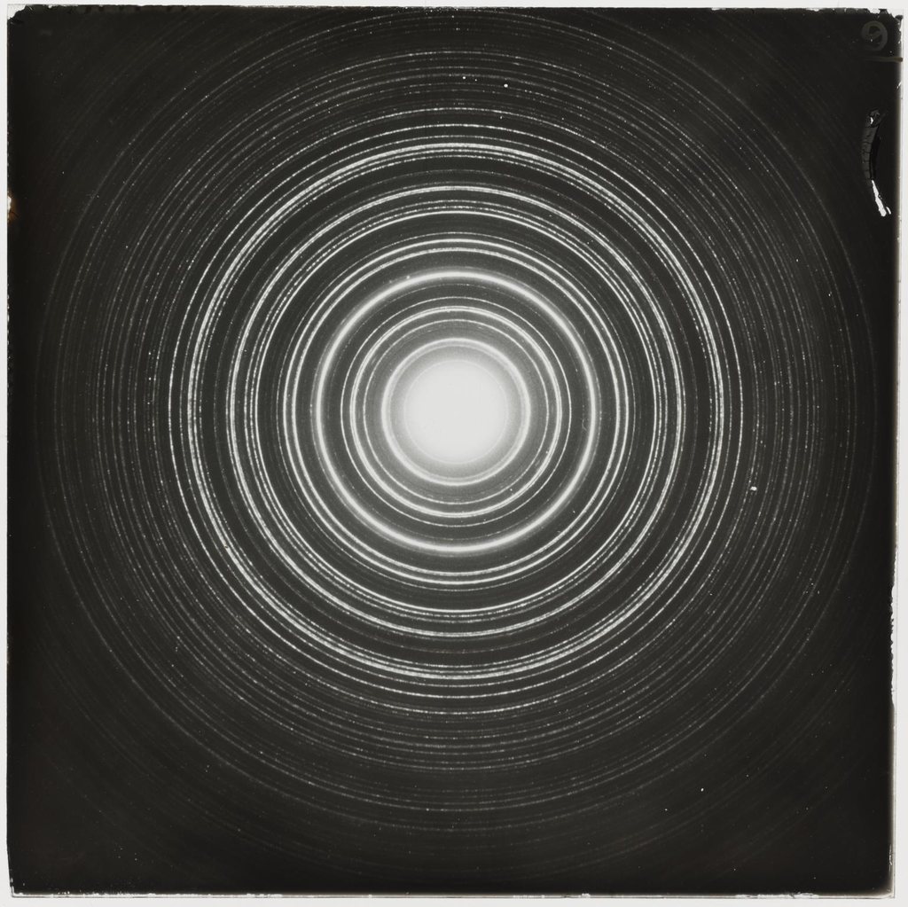

Figure 2: Electron diffraction pattern recorded in experiments by George Paget Thomson. The concentric rings result from diffraction of electrons transmitted through a thin crystalline film. Source: [Science Museum Group Collection](https://collection.sciencemuseumgroup.org.uk/objects/co5292/set-of-twenty-copies-of-original-electron-diffraction-photographs-photograph). Licensed under [CC BY-NC-SA 4.0](https://creativecommons.org/licenses/by-nc-sa/4.0/).

The two experiments used different geometries but led to the same conclusion: electrons, despite their particle-like properties such as charge and mass, can undergo diffraction. Davisson and Thomson later shared the **1937 Nobel Prize in Physics** for the experimental discovery of electron diffraction.

The experiments provided direct evidence that electrons possess a wavelength. We will return to the quantitative relation between wavelength and momentum in Section 5.

**NoteHistorical note**

George Paget Thomson was the son of **J. J. Thomson**, whose cathode-ray experiments helped establish the electron as a constituent of matter with particle-like properties. About three decades later, G. P. Thomson’s diffraction experiments provided direct evidence for the electron’s wave-like behavior.

# 2. Waves and Complex Wave Amplitudes

## 2.1 A traveling wave

A one-dimensional harmonic traveling wave can be written as

$$y(x,t)=A\cos\big(kx-\omega t+\phi\big).$$

It is useful to define the **phase** of the wave as the complete argument of the trigonometric function,

$$\theta(x,t)=kx-\omega t+\phi.$$

Here,

- $A$ is the **amplitude**,
- $\lambda$ is the **wavelength**,
- $k=2\pi/\lambda$ is the **wave number**,
- $f$ is the frequency,
- $\omega=2\pi f$ is the **angular frequency**,
- $\theta(x,t)$ is the **phase** of the wave,
- $\phi$ is the **phase offset** (or initial phase).

Thus, in these notes the word *phase* refers to the full quantity $\theta(x,t)$, while $\phi$ denotes only the constant phase offset.

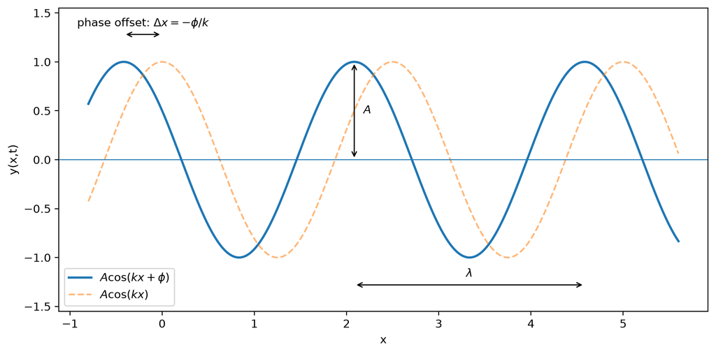

Figure 3: A harmonic wave at fixed time. The figure illustrates the amplitude A, wavelength λ, and the spatial shift associated with a phase offset φ.

```python
import numpy as np
import matplotlib.pyplot as plt

A = 1.0
lam = 2.5
phi = np.pi/3
k = 2*np.pi/lam

x = np.linspace(-0.8, 5.6, 1000)
y = A*np.cos(k*x + phi)
y_ref = A*np.cos(k*x)

x_peak = -phi/k
x_peak_2 = x_peak + lam
x_peak_3 = x_peak + 2*lam

fig, ax = plt.subplots(figsize=(9,4.5))
ax.plot(x, y, linewidth=2, label=r'$A\cos(kx+\phi)$')
ax.plot(x, y_ref, '--', alpha=0.55, label=r'$A\cos(kx)$')
ax.axhline(0, linewidth=0.8)

# Amplitude
ax.annotate('', xy=(x_peak_2, A), xytext=(x_peak_2, 0),
            arrowprops=dict(arrowstyle='<->'))
ax.text(x_peak_2+0.10, A/2, r'$A$', va='center')

# Wavelength
level = -1.28
ax.annotate('', xy=(x_peak_3, level), xytext=(x_peak_2, level),
            arrowprops=dict(arrowstyle='<->'))
ax.text((x_peak_2+x_peak_3)/2, level+0.08, r'$\lambda$', ha='center')

# Shift associated with phase offset
phase_level = 1.28
ax.annotate('', xy=(0, phase_level), xytext=(x_peak, phase_level),
            arrowprops=dict(arrowstyle='<->'))
ax.text(x_peak/2, phase_level+0.08,
        r'phase offset: $\Delta x=-\phi/k$', ha='center')

ax.set_xlabel('x')
ax.set_ylabel('y(x,t)')
ax.set_ylim(-1.55,1.55)
ax.legend(loc='lower left')
ax.grid(False)
plt.tight_layout()
```

A change in phase offset corresponds to a horizontal shift of the wave. At fixed time,

$$\Delta x=-\frac{\phi}{k}.$$

More importantly for interference, two waves need not have the same phase at a given position. Their **relative phase** will determine whether they interfere constructively or destructively.

## 2.2 Complex representation

Using Euler’s relation,

$$e^{i\theta}=\cos\theta+i\sin\theta,$$

we can represent a harmonic wave compactly as

$$\psi(x,t)=A e^{i\theta(x,t)}
=Ae^{i(kx-\omega t+\phi)}.$$

In three dimensions,

$$\psi(\vec r,t)=A e^{i(\vec k\cdot\vec r-\omega t+\phi)}.$$

The complex representation keeps track of both **amplitude and phase** and makes the mathematics of superposition particularly simple.

For a classical wave, the complex notation is often only a mathematical convenience and the measurable quantity is obtained from the real part. In quantum mechanics, by contrast, the wave function $\psi$ is itself generally complex and has a different physical interpretation, which we will introduce in Section 4.

# 3. Superposition and Interference

For two waves with amplitudes $A_1$ and $A_2$,

$$\psi_1=A_1e^{i\theta_1},
\qquad
\psi_2=A_2e^{i\theta_2},$$

the **superposition principle** states that the combined wave is

$$\psi=\psi_1+\psi_2.$$

For ordinary wave intensity, and later for quantum-mechanical probability, the relevant quantity is the absolute square:

$$|\psi|^2=|\psi_1+\psi_2|^2.$$

Expanding gives

$$\boxed{
|\psi_1+\psi_2|^2
=A_1^2+A_2^2+2A_1A_2\cos(\Delta\theta)
}$$

with

$$\Delta\theta=\theta_2-\theta_1.$$

The last term is the **interference term**. The central result is therefore

$$\boxed{\text{interference is determined by relative phase}.}$$

For equal amplitudes $A_1=A_2=A$,

$$|\psi_1+\psi_2|^2
=2A^2\big[1+\cos(\Delta\theta)\big]
=4A^2\cos^2\left(\frac{\Delta\theta}{2}\right).$$

In a double-slit geometry the phase difference results primarily from the difference in path length,

$$\Delta\theta=k\,\Delta L
=\frac{2\pi}{\lambda}\Delta L.$$

For slits separated by $d$ in the far-field approximation,

$$\Delta L\simeq d\sin\alpha.$$

Thus different positions on the observation screen correspond to different relative phases and therefore to alternating constructive and destructive interference.

**NoteDerivation of the interference term**

Starting from

$$\psi=\psi_1+\psi_2,$$

we obtain

$$\begin{aligned}
|\psi|^2
&=(\psi_1+\psi_2)^*(\psi_1+\psi_2)\\
&=|\psi_1|^2+|\psi_2|^2+\psi_1^*\psi_2+\psi_2^*\psi_1.
\end{aligned}$$

For $\psi_j=A_j e^{i\theta_j}$,

$$\psi_1^*\psi_2=A_1A_2e^{i(\theta_2-\theta_1)},$$

and

$$\psi_2^*\psi_1=A_1A_2e^{-i(\theta_2-\theta_1)}.$$

Using $e^{i\alpha}+e^{-i\alpha}=2\cos\alpha$ gives

$$|\psi|^2=A_1^2+A_2^2+2A_1A_2\cos(\theta_2-\theta_1).$$

```python
# echo: false

from diffractio import degrees, mm, np, um
from diffractio.scalar_sources_X import Scalar_source_X
from diffractio.scalar_masks_X import Scalar_mask_X
from diffractio.scalar_masks_XZ import Scalar_mask_XZ

import matplotlib.pyplot as plt
import matplotlib.animation as animation
from IPython.display import HTML, display

import math


# Computational grid
x0 = np.linspace(-37.5 * um, 37.5 * um, 640)
z0 = np.linspace(0 * um, 60 * um, 512)

wavelength = 2 * um


# Incident plane wave
u0 = Scalar_source_X(x=x0, wavelength=wavelength)
u0.plane_wave(theta=0)


# Double slit
t0 = Scalar_mask_X(x=x0, wavelength=wavelength)

t0.double_slit(
    x0=0,
    size=2 * um,
    separation=8 * um
)


# XZ propagation region
t1 = Scalar_mask_XZ(
    x=x0,
    z=z0,
    wavelength=wavelength,
    n_background=1
)

za = 10 * um
zb = za + 1 * um

v_globals = dict(z0=za, z1=zb)

t1.extrude_mask(
    t=t0,
    z0=za,
    z1=zb,
    refractive_index=0 + 20j,
    v_globals=v_globals
)


# Illuminate the mask
t1.incident_field(u0)


# Propagate
t1.WPM(
    has_edges=True,
    pow_edge=60
)


# Complex field
field = np.transpose(t1.u)

field = field[64:-64, 64:]

x_plot = x0[64:-64] / um
z_plot = z0[64:-64] / um


# Animation
fps = 20
n_frames = 20

fig, ax = plt.subplots(figsize=(8, 8))

im = ax.imshow(
    field.real,
    origin="lower",
    aspect="auto",
    extent=[
        x_plot.min(),
        x_plot.max(),
        z_plot.min(),
        z_plot.max()
    ],
    cmap="seismic",
    vmin=-2,
    vmax=2
)

ax.set_xlabel(r"Propagation distance $z$ ($\mu$m)")
ax.set_ylabel(r"Transverse position $x$ ($\mu$m)")
ax.set_title("Double-slit diffraction")


def animate_func(i):
    phase = np.exp(-1j * 2 * np.pi * i / n_frames)
    instantaneous_field = field * phase
    im.set_data(instantaneous_field.real)
    return [im]


anim = animation.FuncAnimation(
    fig,
    animate_func,
    frames=n_frames,
    interval=1000 / fps,
    blit=True,
    repeat=True
)

plt.close(fig)

display(HTML(anim.to_html5_video()))
```

[video not shown]

Double-slit interference. Instantaneous real part of a monochromatic wave propagating through two narrow slits. The waves emerging from the slits overlap and interfere as they propagate.

# 4. Probability and the Born Rule

## 4.1 Probability distributions

Before assigning a physical meaning to the quantum-mechanical wave function, we briefly review probability densities.

Let $p(x)$ be a probability density. The probability of finding a measurement outcome between $a$ and $b$ is

$$P(a<x<b)=\int_a^b p(x)\,dx.$$

The total probability must be one,

$$\int_{-\infty}^{\infty}p(x)\,dx=1.$$

For a very small interval $dx$,

$$dP=p(x)\,dx.$$

The expectation value is

$$\langle x\rangle
=\int_{-\infty}^{\infty}x\,p(x)\,dx,$$

and the variance is

$$\operatorname{Var}(x)
=\langle x^2\rangle-\langle x\rangle^2.$$

The standard deviation is

$$\sigma_x=\sqrt{\operatorname{Var}(x)}.$$

## 4.2 The Born interpretation

Quantum mechanics associates a complex wave function $\psi(\vec r,t)$ with the state of a particle. According to the **Born rule**, the probability density for position is

$$\boxed{p(\vec r,t)=|\psi(\vec r,t)|^2.}$$

Thus the probability of detecting the particle within a small volume $d^3r$ is

$$dP=|\psi(\vec r,t)|^2\,d^3r,$$

and the probability of finding it in a finite region $R$ is

$$P_R=\int_R |\psi(\vec r,t)|^2\,d^3r.$$

For a normalizable state,

$$\int_{\mathbb R^3}|\psi(\vec r,t)|^2\,d^3r=1.$$

This gives the wave function its central interpretation:

$$\boxed{\psi=\text{probability amplitude},
\qquad |\psi|^2=\text{probability density}.}$$

The electron-interference experiment can now be expressed very compactly. The probability amplitudes associated with the two alternatives add,

$$\psi=\psi_1+\psi_2,$$

but the measurable probability density is

$$|\psi|^2=|\psi_1+\psi_2|^2,$$

which contains the interference term.

**Note**

A plane wave extending over all space is not square-normalizable in the usual sense. It is an idealized state of exactly defined momentum and can be treated using box normalization or the generalized normalization of continuum states.

# 5. Matter Waves and the de Broglie Relations

The experiments discussed in Section 1 show that particles can exhibit wave-like behavior. de Broglie proposed that the momentum of a particle is related to its wave vector by

$$\boxed{\vec p=\hbar\vec k}$$

or equivalently

$$\boxed{\lambda=\frac{h}{p}.}$$

The corresponding relation between energy and angular frequency is

$$\boxed{E=\hbar\omega.}$$

These relations connect particle quantities $(E,\vec p)$ to wave quantities $(\omega,\vec k)$.

For a one-dimensional plane wave,

$$\psi(x,t)=A e^{i(kx-\omega t)},$$

the momentum and energy are therefore

$$p=\hbar k,
\qquad
E=\hbar\omega.$$

The probability density of an ideal plane wave is constant,

$$|\psi(x,t)|^2=|A|^2,$$

so it is completely delocalized in position. This is consistent with the plane wave representing a state of precisely defined momentum.

## 5.1 Wave packets and momentum space

A localized particle cannot be represented by a single plane wave. Instead, it is represented by a **superposition of plane waves** with different wave vectors.

In one dimension,

$$\tilde\psi(k)
=\frac{1}{\sqrt{2\pi}}
\int_{-\infty}^{\infty}
\psi(x)e^{-ikx}\,dx,$$

and

$$\psi(x)
=\frac{1}{\sqrt{2\pi}}
\int_{-\infty}^{\infty}
\tilde\psi(k)e^{ikx}\,dk.$$

Because $p=\hbar k$, the distribution in $k$ is directly related to the distribution of momentum. A narrow range of wave vectors produces an extended wave packet in position, while strong localization requires a broader range of wave vectors. This relation will later lead naturally to the position–momentum uncertainty relation.

# 6. Time Evolution and the Schrödinger Equation

## 6.1 Energy and momentum as differential operators

Consider again a plane wave,

$$\psi(x,t)=Ae^{i(kx-\omega t)}.$$

Taking a time derivative gives

$$\frac{\partial\psi}{\partial t}
=-i\omega\psi,$$

and therefore, using $E=\hbar\omega$,

$$i\hbar\frac{\partial\psi}{\partial t}=E\psi.$$

Similarly,

$$\frac{\partial\psi}{\partial x}=ik\psi,$$

so that, using $p=\hbar k$,

$$-i\hbar\frac{\partial\psi}{\partial x}=p\psi.$$

This motivates the quantum-mechanical associations

$$\boxed{
E\longleftrightarrow i\hbar\frac{\partial}{\partial t},
\qquad
p_x\longleftrightarrow -i\hbar\frac{\partial}{\partial x}.
}$$

In three dimensions,

$$\boxed{\hat{\vec p}=-i\hbar\vec\nabla.}$$

These are examples of **operators**: mathematical objects that act on a wave function. Operators and their general role in quantum mechanics are discussed in the next chapter.

## 6.2 Potential energy and the Hamiltonian

For a nonrelativistic classical particle,

$$E=T+V=\frac{p^2}{2m}+V.$$

Here $V(\vec r,t)$ is the **potential energy** that describes the interaction of the particle with its environment. Examples include

$$V=mgh$$

for a particle near the surface of the Earth and

$$V=q\Phi$$

for a charge $q$ in an electrostatic potential $\Phi$.

In atomic physics, the Coulomb interaction between an electron and a nucleus of charge $+Ze$ gives

$$V(r)=-\frac{Ze^2}{4\pi\varepsilon_0 r}.$$

Replacing the classical energy and momentum quantities by the corresponding quantum-mechanical operators motivates

$$\boxed{
i\hbar\frac{\partial}{\partial t}\psi(\vec r,t)
=\left[
-\frac{\hbar^2}{2m}\nabla^2+V(\vec r,t)
\right]\psi(\vec r,t).
}$$

This is the **time-dependent Schrödinger equation**.

Defining the Hamiltonian operator

$$\boxed{
\hat H=-\frac{\hbar^2}{2m}\nabla^2+V(\vec r,t),
}$$

it can be written compactly as

$$\boxed{
i\hbar\frac{\partial}{\partial t}\psi=\hat H\psi.
}$$

**Important**

The argument above **motivates** the form of the Schrödinger equation; it is not a derivation from classical mechanics. Within nonrelativistic quantum mechanics, the Schrödinger equation is a fundamental dynamical law.

## 6.3 Time-independent Schrödinger equation

If the potential has no explicit time dependence,

$$V(\vec r,t)=V(\vec r),$$

states of well-defined energy can be written as

$$\psi(\vec r,t)=\phi(\vec r)e^{-iEt/\hbar}
=\phi(\vec r)e^{-i\omega t}.$$

Substitution into the time-dependent Schrödinger equation gives

$$\boxed{
\hat H\phi(\vec r)=E\phi(\vec r),
}$$

the **time-independent Schrödinger equation**.

Because the time-dependent factor has unit magnitude,

$$|e^{-iEt/\hbar}|^2=1,$$

the position probability density of such an energy eigenstate is time independent:

$$|\psi(\vec r,t)|^2=|\phi(\vec r)|^2.$$

Such states are therefore called **stationary states**.

## 6.4 Example: a free Gaussian wave packet

A physically localized particle can be represented by a wave packet. A convenient initial state is a Gaussian packet,

$$\psi(x,0)
=\frac{1}{(2\pi\sigma_0^2)^{1/4}}
\exp\left[-\frac{(x-x_0)^2}{4\sigma_0^2}\right]
e^{ik_0x}.$$

Its initial probability distribution has standard deviation $\sigma_0$. For a free particle the center moves with the group velocity

$$v_g=\frac{\hbar k_0}{m},$$

while the packet spreads according to

$$\sigma(t)
=\sigma_0
\sqrt{1+\left(\frac{\hbar t}{2m\sigma_0^2}\right)^2}.$$

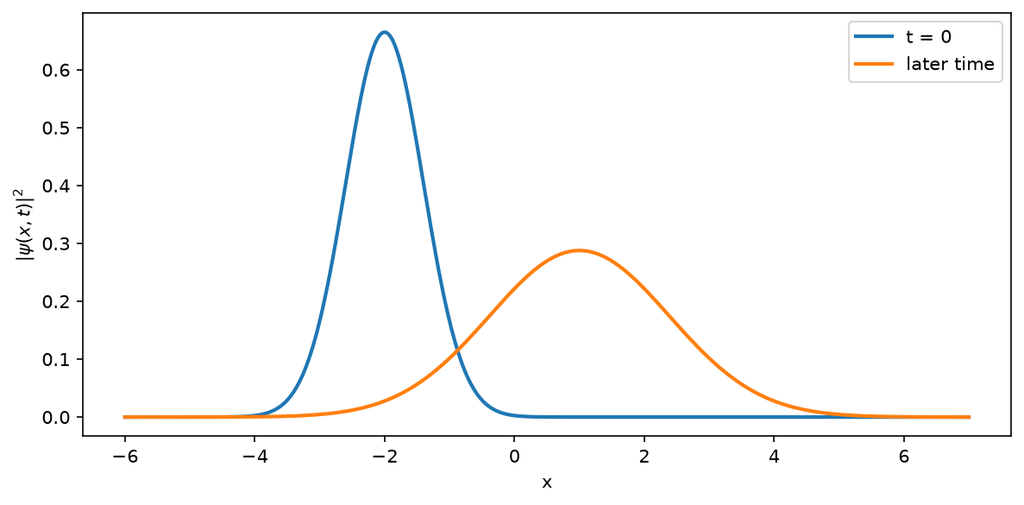

Figure 4: Free Gaussian wave packet: the center moves while the position distribution spreads with time. Dimensionless units with ħ=m=1 are used.

```python
import numpy as np
import matplotlib.pyplot as plt

hbar = 1.0
m = 1.0
sigma0 = 0.6
x0 = -2.0
k0 = 2.0

x = np.linspace(-6, 7, 800)

def probability_density(x, t):
    sigma_t = sigma0*np.sqrt(1 + (hbar*t/(2*m*sigma0**2))**2)
    x_center = x0 + hbar*k0*t/m
    return np.exp(-(x-x_center)**2/(2*sigma_t**2))/(np.sqrt(2*np.pi)*sigma_t)

fig, ax = plt.subplots(figsize=(8,4))
ax.plot(x, probability_density(x,0), linewidth=2, label='t = 0')
ax.plot(x, probability_density(x,1.5), linewidth=2, label='later time')
ax.set_xlabel('x')
ax.set_ylabel(r'$|\psi(x,t)|^2$')
ax.legend()
ax.grid(False)
plt.tight_layout()
```

The wave packet illustrates several important ideas at once:

- a localized state is a **superposition of plane waves**;
- its center moves with the group velocity;
- its position distribution can spread with time;
- unlike an ideal plane wave, a Gaussian wave packet is square-normalizable.

## Additional remarks

- Analytic solutions of the Schrödinger equation exist only for a limited number of systems. Approximation methods and numerical solutions are therefore essential in atomic and molecular physics.
- The nonrelativistic Schrödinger equation is not sufficient when relativistic effects become important. Relativistic quantum mechanics leads to equations such as the Dirac equation, and a fully quantized treatment of electromagnetic interactions requires quantum electrodynamics.
- A scalar spatial wave function is not sufficient to describe all quantum degrees of freedom. Electron spin, for example, requires a two-component spinor structure, which will be introduced later in the course.